# 游戏相关岗位招聘和薪酬水平

## 总述

本次采集有效数据5382条(城市发布量>=100),主要分析游戏相关岗位招聘和薪酬水平，我们将从如下方面分析：

- 01.城市分布：广州占31%，平均月薪16106元；上海占20%，平均月薪20701元；深圳占15%，平均月薪17900元。
- 02.行业分布：网游占47%，平均月薪16885元；计算机软件占22%，平均月薪16018元；电商占14%，平均月薪18522元。
- 03.公司规模：1000人以下占82%，平均月薪15385元；1000-5000人和5000人以上均占9%，平均月薪分别为20996元和22503元。
- 04.公司类型：民企占80%，平均月薪16103元；外企占4%，平均月薪16107元。
- 05.工作经验：5年以下占88%，平均月薪14765元；5-10年占12%，平均月薪29672元。
- 06.学历要求：大专占58%，平均月薪15199元；本科占39%，平均月薪19112元。
- 07.细分岗位：其他占76%，平均月薪17441元。其他包括：UE4开发、系统/剧情策划、角色/特效/动作/场景/关卡/界面/2D/3D设计、原画师、动画师、电子竞技等。

## 01.城市分布

[figure not shown]

roadmap

## 02.行业分布

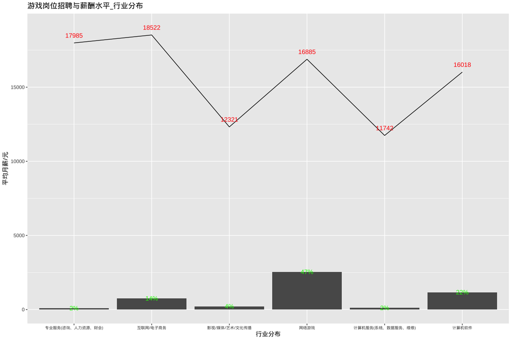

industries

## 03.公司规模

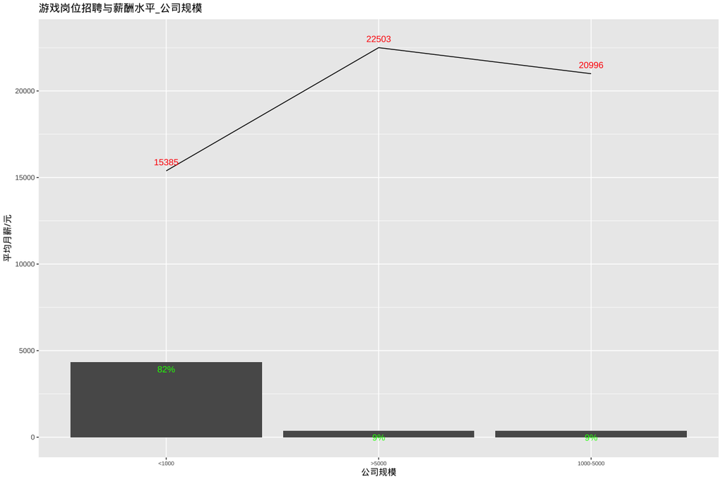

com_size

## 04.公司类型

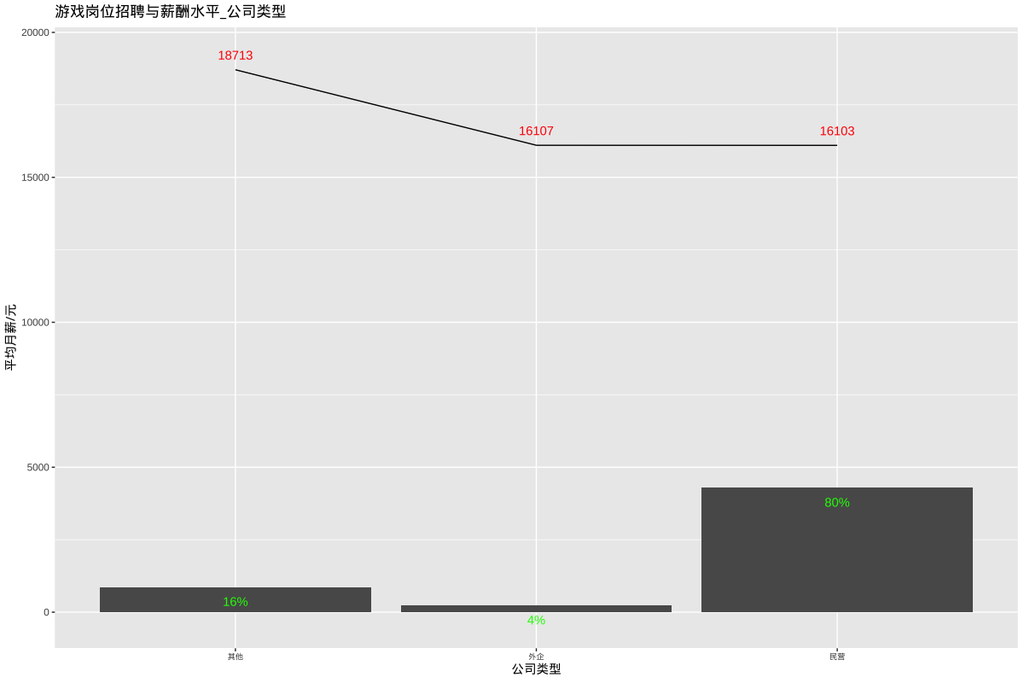

com_type

## 05.工作经验

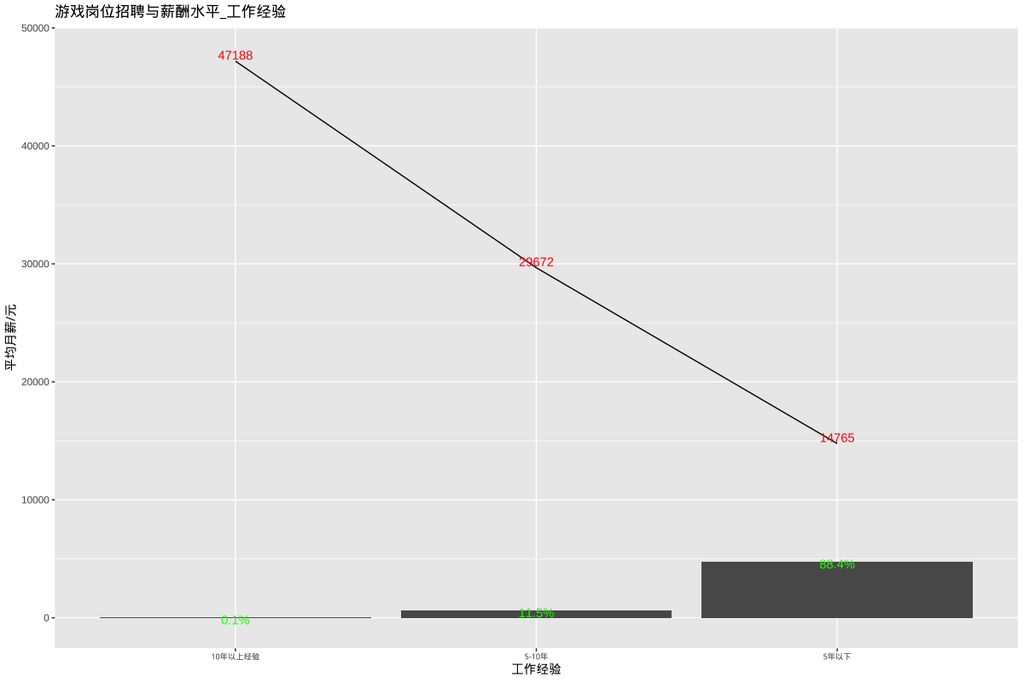

experience

## 06.学历要求

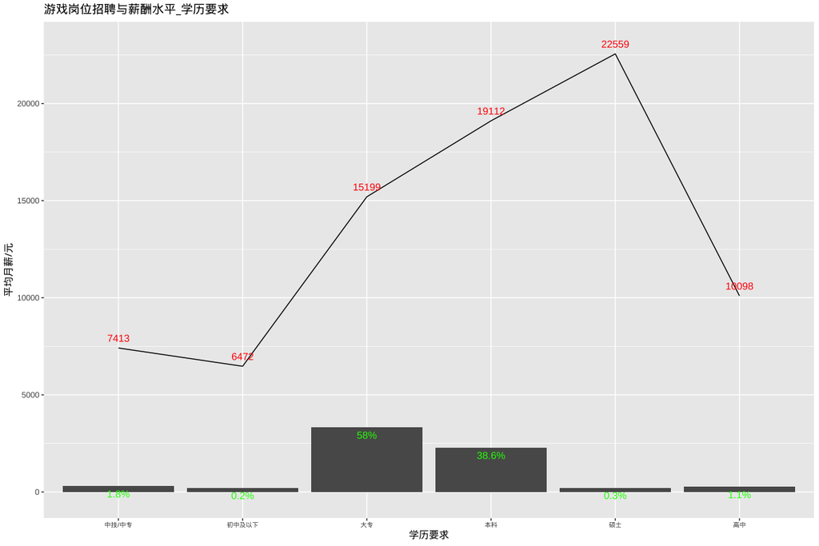

education

## 07.细分岗位

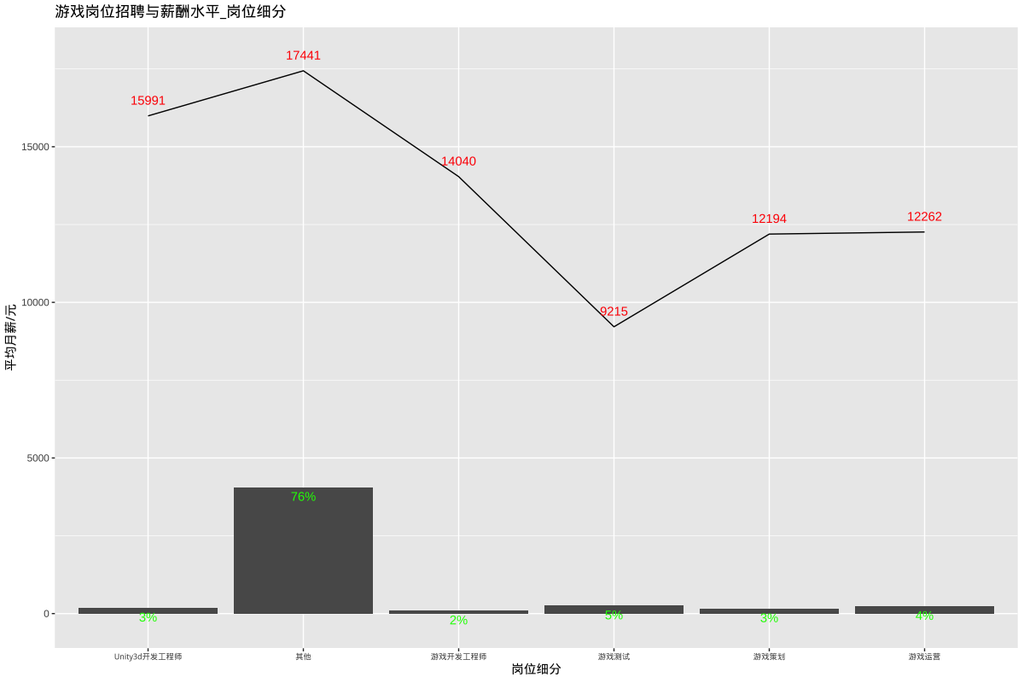

subclass